# Лабораторная работа №11

по курсу: Архитектура компьютера и операционные системы

Иванова Анастасия Сергеевна

1132250427@rudn.ru

Российский университет дружбы народов

2026-04-25

# Докладчик

- Иванова Анастасия Сергеевна
- 1 курс группа НКАбд-07-25
- Российский университет дружбы народов
- 1132250427@rudn.ru

# **Вводная часть**

## Актуальность темы

- Редактор Emacs является одним из самых мощных и настраиваемых текстовых редакторов в мире
- Широко используется разработчиками, системными администраторами и исследователями благодаря своей расширяемости
- Поддерживает множество языков программирования, интеграцию с системами контроля версий и средствами отладки
- Освоение Emacs позволяет значительно повысить эффективность работы с текстом и кодом

## Объект и предмет исследования

**Объект исследования:** - Текстовый редактор Emacs - Режимы работы и система комбинаций клавиш - Архитектура расширений на языке Elisp

**Предмет исследования:** - Процесс создания и редактирования текстовых файлов с помощью Emacs - Основные комбинации клавиш для навигации, редактирования и управления буферами - Способы работы с несколькими окнами и буферами - Функции поиска и замены текста

## Цели

- Познакомиться с операционной системой Linux
- Получить практические навыки работы с редактором Emacs

# **Выполнение лабораторной работы**

## **Задание 1. Основные команды emacs**

1. Откроем emacs (рис. 1):

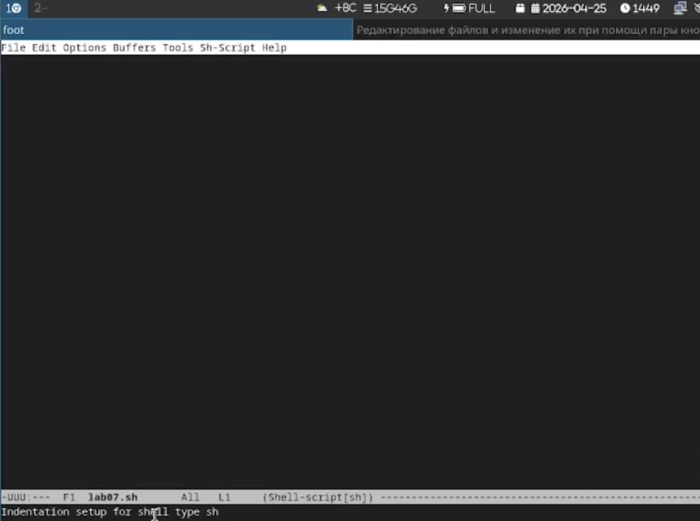

Рисунок 1: Запуск emacs

2. Создадим файл lab07.sh с помощью комбинации `C-x C-f` (рис. 2):

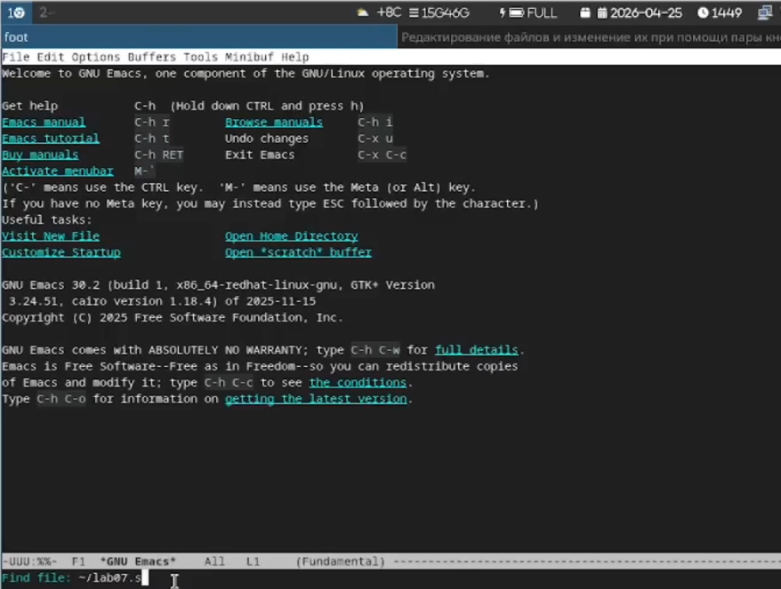

Рисунок 2: Создание файла

3. Наберём текст (рис. 3):

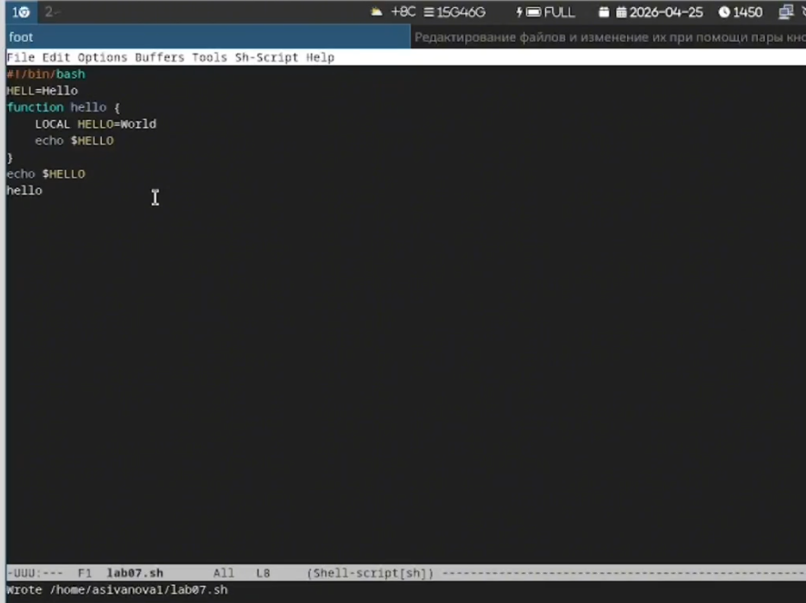

Рисунок 3: Ввод текста

Текст файла:

```bash
#!/bin/bash
HELL=Hello
function hello {
    LOCAL HELLO=World
    echo $HELLO
}
echo $HELLO
hello
```

4. Сохраним файл с помощью комбинации `C-x C-s` (рис. 4):

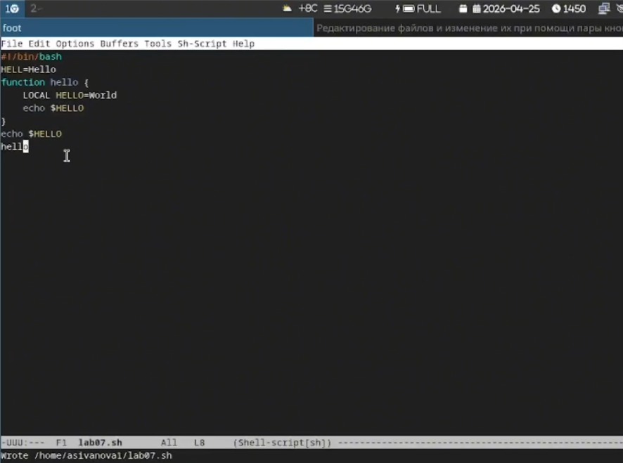

Рисунок 4: Сохранение файла

## **Задание 2. Редактирование текста**

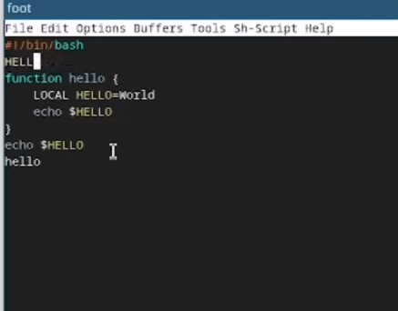

Рисунок 5: Вырезание строки

5.2. Вставим эту строку в конец файла (`C-y`) (рис. 6):

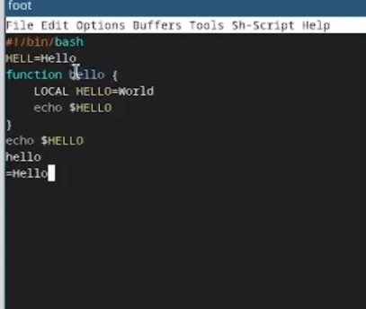

Рисунок 6: Вставка строки

5.3. Выделим область текста (`C-space`) (рис. 7):

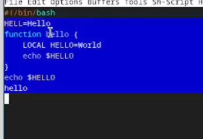

Рисунок 7: Выделение текста

5.4. Скопируем область в буфер обмена (`M-w`) (рис. 8):

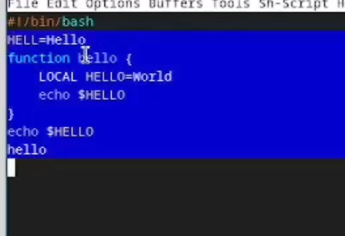

Рисунок 8: Копирование области

5.5. Вставим область в конец файла (`C-y`) (рис. 9):

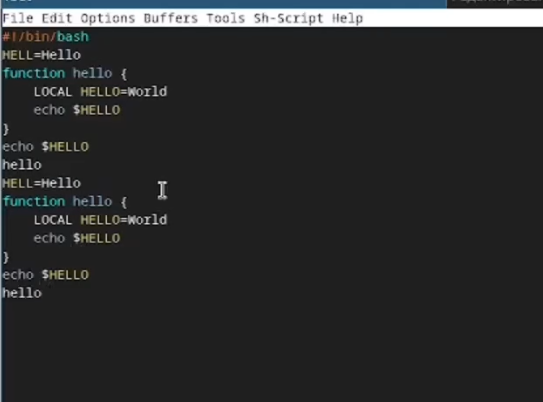

Рисунок 9: Вставка области

5.6. Вновь выделим эту область и вырежем её (`C-w`) (рис. 10):

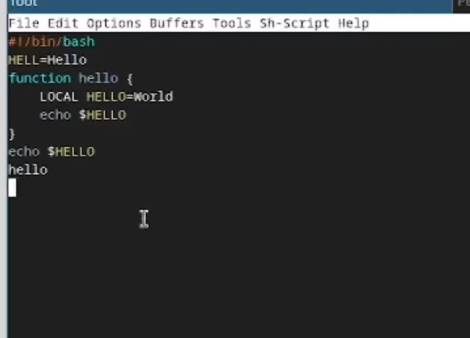

Рисунок 10: Вырезание области

5.7. Отменим последнее действие (`C-/`) (рис. 11):

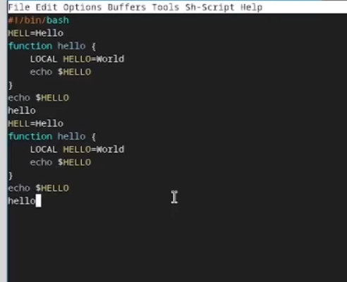

Рисунок 11: Отмена действия

## **Задание 3. Перемещение курсора**

6.1. Переместим курсор в начало строки (`C-a`) (рис. 12):

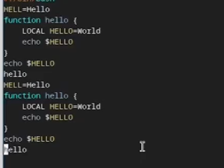

Рисунок 12: Начало строки

6.2. Переместим курсор в конец строки (`C-e`) (рис. 13):

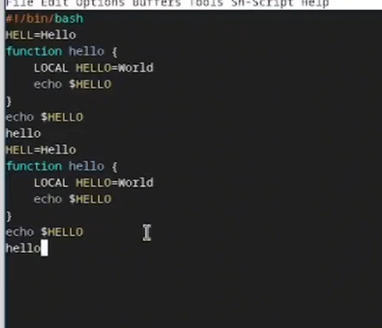

Рисунок 13: Конец строки

6.3. Переместим курсор в начало буфера (`M-<`) (рис. 14):

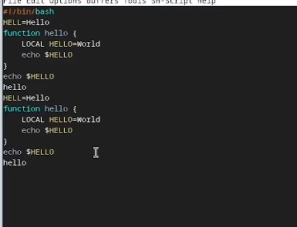

Рисунок 14: Начало буфера

6.4. Переместим курсор в конец буфера (`M->`) (рис. 15):

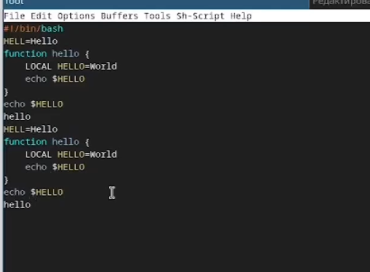

Рисунок 15: Конец буфера

## **Задание 4. Управление буферами**

7.1. Выведем список активных буферов на экран (`C-x C-b`) (рис. 16):

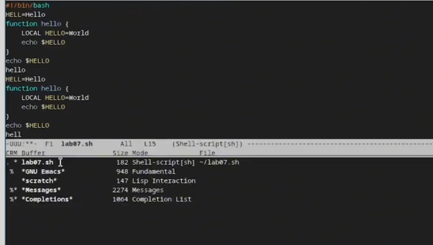

Рисунок 16: Список буферов

7.2. Переместимся во вновь открытое окно со списком буферов (`C-x o`) (рис. 17):

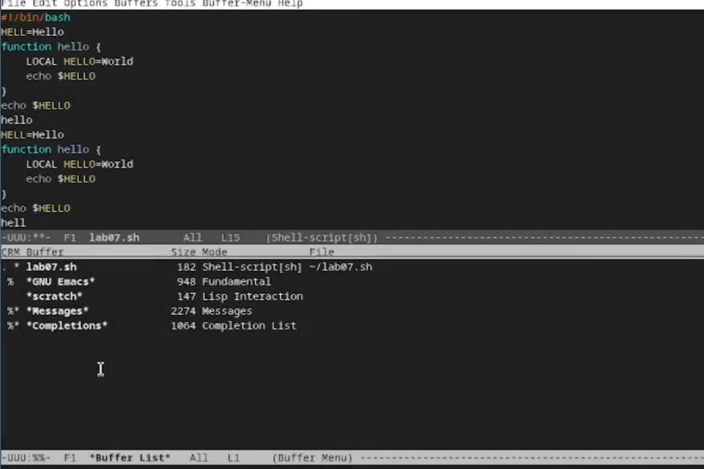

Рисунок 17: Перемещение в другое окно

7.3. Закроем это окно (`C-x 0`) (рис. 18):

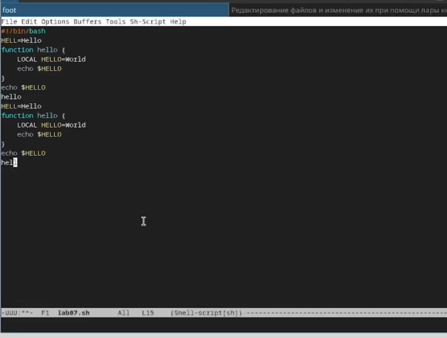

Рисунок 18: Закрытие окна

7.4. Переключимся между буферами без вывода списка на экран (`C-x b`) (рис. 19):

[figure not shown]

Рисунок 19: Переключение буферов

## **Задание 5. Управление окнами**

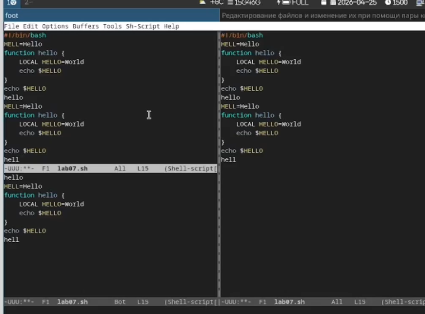

Рисунок 20: Разделение окон

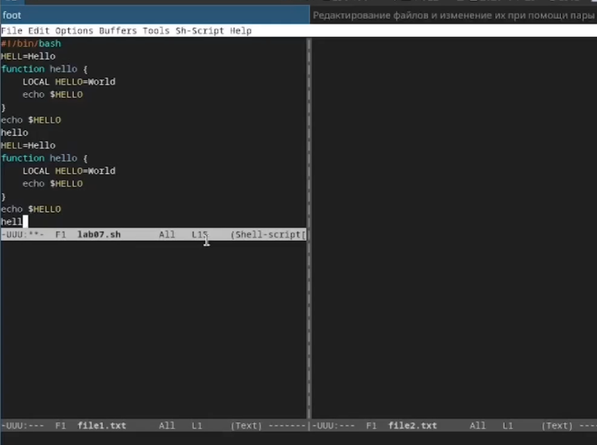

## **Задание 6. Поиск и замена**

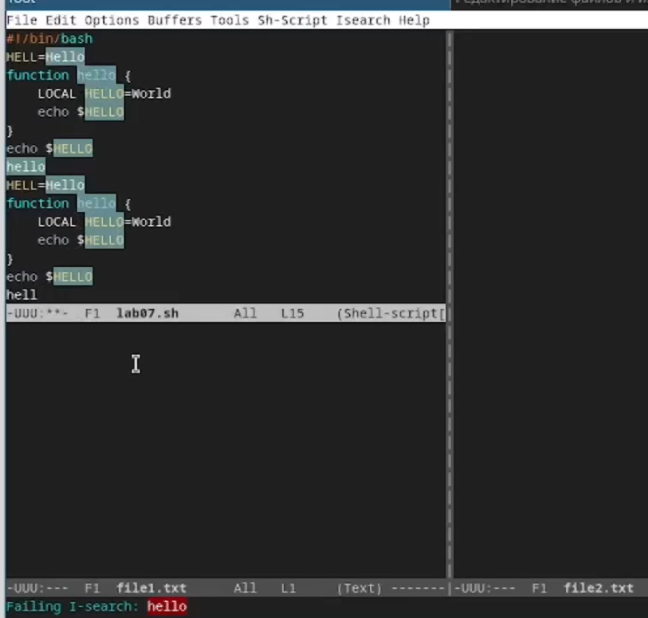

Рисунок 22: Поиск текста

9.2. Переключимся между результатами поиска, нажимая `C-s` (рис. 23):

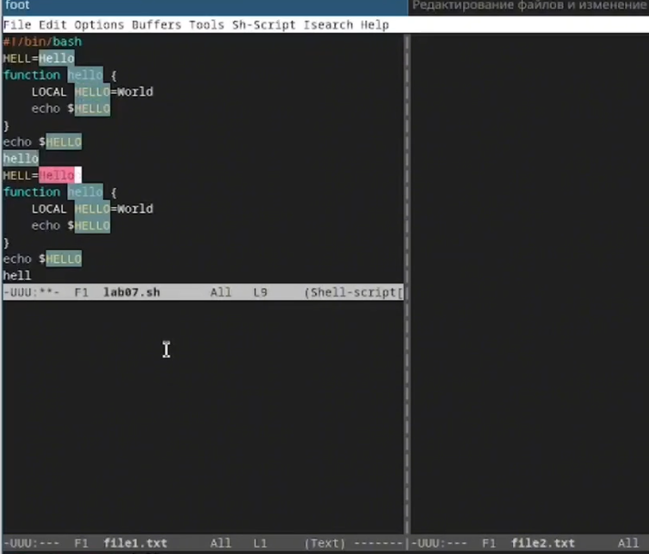

Рисунок 23: Переключение результатов поиска

9.3. Выйдем из режима поиска, нажав `C-g` (рис. 24):

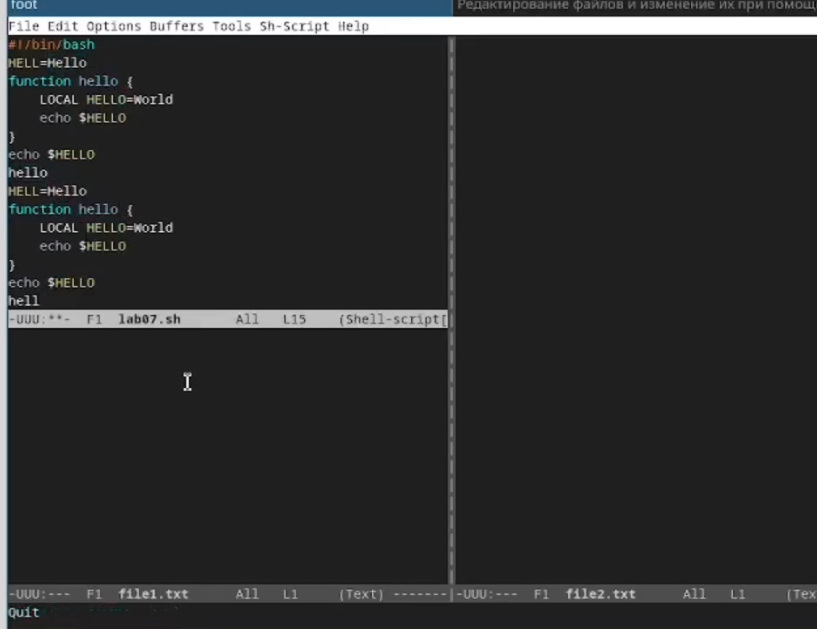

Рисунок 24: Выход из поиска

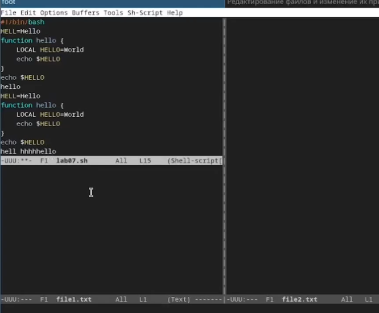

Рисунок 25: Поиск и замена

# **Контрольные вопросы**

**1. Кратко охарактеризуйте редактор emacs.**

Emacs — мощный экранный редактор текста, написанный на языке высокого уровня Elisp. Поддерживает множество режимов, расширений и может быть настроен под любые задачи.

**2. Какие особенности данного редактора могут сделать его сложным для освоения новичком?**

Сложность в большом количестве комбинаций клавиш, неочевидных для новичка. Многие действия выполняются через `Ctrl` и `Meta` (Alt), а не через меню. Также Emacs имеет собственную философию и терминологию (буферы, фреймы, окна).

**3. Своими словами опишите, что такое буфер и окно в терминологии emacs’а.**

- **Буфер** — объект, содержащий какой-либо текст (файл, результаты компиляции, сообщения, справку). Буфер может быть не связан с файлом на диске.
- **Окно** — прямоугольная область фрейма, отображающая один буфер. Один фрейм может содержать несколько окон.

**4. Можно ли открыть больше 10 буферов в одном окне?**

Да, количество буферов не ограничено. Окно показывает один буфер в каждый момент времени, но переключаться между буферами можно в любом количестве.

**5. Какие буферы создаются по умолчанию при запуске emacs?**

По умолчанию создаются: `*scratch*` (черновик для временных записей), `*Messages*` (буфер с системными сообщениями), `*GNU Emacs*` (приветственное окно).

**7. Как поделить текущее окно на две части?**

- По горизонтали (верх/низ): `C-x 2`
- По вертикали (лево/право): `C-x 3`

**8. В каком файле хранятся настройки редактора emacs?**

Настройки хранятся в файле `~/.emacs` или в каталоге `~/.emacs.d/init.el`.

**9. Какую функцию выполняет клавиша ← и можно ли её переназначить?**

Клавиша `←` (влево) перемещает курсор на один символ влево. Да, можно переназначить через `global-set-key` в конфигурационном файле.

**10. Какой редактор вам показался удобнее в работе vi или emacs? Поясните почему.**

Emacs удобнее для повседневной работы благодаря графическому интерфейсу, меню и большому количеству расширений. vi удобнее при работе в консоли и на удалённых серверах, так как он есть в любой Unix-системе по умолчанию.

# **Вывод**

Мы познакомились с операционной системой Linux и получили практические навыки работы с редактором Emacs.